# Risk Factor Analysis

## Outcome Variable

**Outcome Variable:** wast_rec90d

## Predictor Variables

**Intervention Variable:** sex

**Adjustment Set:**

unadjusted

## Stratifying Variables

The analysis was stratified on these variable(s):

- agecat
- studyid
- country

## Data Summary

| agecat | studyid | country | sex | wast_rec90d | n_cell | n | outcome_variable |
| --- | --- | --- | --- | --- | --- | --- | --- |
| 0-24 months | ki0047075b-MAL-ED | BANGLADESH | Female | 0 | 28 | 124 | wast_rec90d |
| 0-24 months | ki0047075b-MAL-ED | BANGLADESH | Female | 1 | 43 | 124 | wast_rec90d |
| 0-24 months | ki0047075b-MAL-ED | BANGLADESH | Male | 0 | 16 | 124 | wast_rec90d |
| 0-24 months | ki0047075b-MAL-ED | BANGLADESH | Male | 1 | 37 | 124 | wast_rec90d |
| 0-24 months | ki0047075b-MAL-ED | BRAZIL | Female | 0 | 4 | 24 | wast_rec90d |
| 0-24 months | ki0047075b-MAL-ED | BRAZIL | Female | 1 | 5 | 24 | wast_rec90d |
| 0-24 months | ki0047075b-MAL-ED | BRAZIL | Male | 0 | 2 | 24 | wast_rec90d |
| 0-24 months | ki0047075b-MAL-ED | BRAZIL | Male | 1 | 13 | 24 | wast_rec90d |
| 0-24 months | ki0047075b-MAL-ED | INDIA | Female | 0 | 32 | 181 | wast_rec90d |
| 0-24 months | ki0047075b-MAL-ED | INDIA | Female | 1 | 66 | 181 | wast_rec90d |
| 0-24 months | ki0047075b-MAL-ED | INDIA | Male | 0 | 39 | 181 | wast_rec90d |
| 0-24 months | ki0047075b-MAL-ED | INDIA | Male | 1 | 44 | 181 | wast_rec90d |
| 0-24 months | ki0047075b-MAL-ED | NEPAL | Female | 0 | 6 | 98 | wast_rec90d |
| 0-24 months | ki0047075b-MAL-ED | NEPAL | Female | 1 | 41 | 98 | wast_rec90d |
| 0-24 months | ki0047075b-MAL-ED | NEPAL | Male | 0 | 14 | 98 | wast_rec90d |
| 0-24 months | ki0047075b-MAL-ED | NEPAL | Male | 1 | 37 | 98 | wast_rec90d |
| 0-24 months | ki0047075b-MAL-ED | PERU | Female | 0 | 1 | 35 | wast_rec90d |
| 0-24 months | ki0047075b-MAL-ED | PERU | Female | 1 | 10 | 35 | wast_rec90d |
| 0-24 months | ki0047075b-MAL-ED | PERU | Male | 0 | 5 | 35 | wast_rec90d |
| 0-24 months | ki0047075b-MAL-ED | PERU | Male | 1 | 19 | 35 | wast_rec90d |
| 0-24 months | ki0047075b-MAL-ED | SOUTH AFRICA | Female | 0 | 8 | 87 | wast_rec90d |
| 0-24 months | ki0047075b-MAL-ED | SOUTH AFRICA | Female | 1 | 29 | 87 | wast_rec90d |
| 0-24 months | ki0047075b-MAL-ED | SOUTH AFRICA | Male | 0 | 10 | 87 | wast_rec90d |
| 0-24 months | ki0047075b-MAL-ED | SOUTH AFRICA | Male | 1 | 40 | 87 | wast_rec90d |
| 0-24 months | ki0047075b-MAL-ED | TANZANIA, UNITED REPUBLIC OF | Female | 0 | 4 | 51 | wast_rec90d |
| 0-24 months | ki0047075b-MAL-ED | TANZANIA, UNITED REPUBLIC OF | Female | 1 | 25 | 51 | wast_rec90d |
| 0-24 months | ki0047075b-MAL-ED | TANZANIA, UNITED REPUBLIC OF | Male | 0 | 5 | 51 | wast_rec90d |
| 0-24 months | ki0047075b-MAL-ED | TANZANIA, UNITED REPUBLIC OF | Male | 1 | 17 | 51 | wast_rec90d |
| 0-24 months | ki1000108-CMC-V-BCS-2002 | INDIA | Female | 0 | 52 | 324 | wast_rec90d |
| 0-24 months | ki1000108-CMC-V-BCS-2002 | INDIA | Female | 1 | 110 | 324 | wast_rec90d |

[output cut: 338 more lines]

The following strata were considered:

- agecat: 0-24 months, studyid: ki0047075b-MAL-ED, country: BANGLADESH
- agecat: 0-24 months, studyid: ki0047075b-MAL-ED, country: BRAZIL
- agecat: 0-24 months, studyid: ki0047075b-MAL-ED, country: INDIA
- agecat: 0-24 months, studyid: ki0047075b-MAL-ED, country: NEPAL
- agecat: 0-24 months, studyid: ki0047075b-MAL-ED, country: PERU
- agecat: 0-24 months, studyid: ki0047075b-MAL-ED, country: SOUTH AFRICA
- agecat: 0-24 months, studyid: ki0047075b-MAL-ED, country: TANZANIA, UNITED REPUBLIC OF
- agecat: 0-24 months, studyid: ki1000108-CMC-V-BCS-2002, country: INDIA
- agecat: 0-24 months, studyid: ki1000108-IRC, country: INDIA
- agecat: 0-24 months, studyid: ki1000109-EE, country: PAKISTAN
- agecat: 0-24 months, studyid: ki1000109-ResPak, country: PAKISTAN
- agecat: 0-24 months, studyid: ki1000304b-SAS-CompFeed, country: INDIA
- agecat: 0-24 months, studyid: ki1000304b-SAS-FoodSuppl, country: INDIA
- agecat: 0-24 months, studyid: ki1017093-NIH-Birth, country: BANGLADESH
- agecat: 0-24 months, studyid: ki1017093b-PROVIDE, country: BANGLADESH
- agecat: 0-24 months, studyid: ki1017093c-NIH-Crypto, country: BANGLADESH
- agecat: 0-24 months, studyid: ki1066203-TanzaniaChild2, country: TANZANIA, UNITED REPUBLIC OF
- agecat: 0-24 months, studyid: ki1101329-Keneba, country: GAMBIA
- agecat: 0-24 months, studyid: ki1112895-Guatemala BSC, country: GUATEMALA
- agecat: 0-24 months, studyid: ki1112895-iLiNS-Zinc, country: BURKINA FASO
- agecat: 0-24 months, studyid: ki1113344-GMS-Nepal, country: NEPAL
- agecat: 0-24 months, studyid: ki1114097-CMIN, country: BANGLADESH
- agecat: 0-24 months, studyid: ki1114097-CONTENT, country: PERU
- agecat: 0-24 months, studyid: ki1119695-PROBIT, country: BELARUS
- agecat: 0-24 months, studyid: ki1126311-ZVITAMBO, country: ZIMBABWE
- agecat: 0-24 months, studyid: ki1135781-COHORTS, country: GUATEMALA
- agecat: 0-24 months, studyid: ki1135781-COHORTS, country: INDIA
- agecat: 0-24 months, studyid: ki1135781-COHORTS, country: PHILIPPINES
- agecat: 0-24 months, studyid: ki1148112-LCNI-5, country: MALAWI
- agecat: 0-24 months, studyid: kiGH5241-JiVitA-3, country: BANGLADESH
- agecat: 0-24 months, studyid: kiGH5241-JiVitA-4, country: BANGLADESH
- agecat: 0-6 months, studyid: ki0047075b-MAL-ED, country: BANGLADESH
- agecat: 0-6 months, studyid: ki0047075b-MAL-ED, country: BRAZIL
- agecat: 0-6 months, studyid: ki0047075b-MAL-ED, country: INDIA
- agecat: 0-6 months, studyid: ki0047075b-MAL-ED, country: NEPAL
- agecat: 0-6 months, studyid: ki0047075b-MAL-ED, country: PERU
- agecat: 0-6 months, studyid: ki0047075b-MAL-ED, country: SOUTH AFRICA
- agecat: 0-6 months, studyid: ki0047075b-MAL-ED, country: TANZANIA, UNITED REPUBLIC OF
- agecat: 0-6 months, studyid: ki1000108-CMC-V-BCS-2002, country: INDIA
- agecat: 0-6 months, studyid: ki1000108-IRC, country: INDIA
- agecat: 0-6 months, studyid: ki1000109-EE, country: PAKISTAN
- agecat: 0-6 months, studyid: ki1000109-ResPak, country: PAKISTAN
- agecat: 0-6 months, studyid: ki1000304b-SAS-CompFeed, country: INDIA
- agecat: 0-6 months, studyid: ki1000304b-SAS-FoodSuppl, country: INDIA
- agecat: 0-6 months, studyid: ki1017093-NIH-Birth, country: BANGLADESH
- agecat: 0-6 months, studyid: ki1017093b-PROVIDE, country: BANGLADESH
- agecat: 0-6 months, studyid: ki1017093c-NIH-Crypto, country: BANGLADESH
- agecat: 0-6 months, studyid: ki1066203-TanzaniaChild2, country: TANZANIA, UNITED REPUBLIC OF
- agecat: 0-6 months, studyid: ki1101329-Keneba, country: GAMBIA
- agecat: 0-6 months, studyid: ki1112895-Guatemala BSC, country: GUATEMALA
- agecat: 0-6 months, studyid: ki1113344-GMS-Nepal, country: NEPAL
- agecat: 0-6 months, studyid: ki1114097-CMIN, country: BANGLADESH
- agecat: 0-6 months, studyid: ki1114097-CONTENT, country: PERU
- agecat: 0-6 months, studyid: ki1119695-PROBIT, country: BELARUS
- agecat: 0-6 months, studyid: ki1126311-ZVITAMBO, country: ZIMBABWE
- agecat: 0-6 months, studyid: ki1135781-COHORTS, country: GUATEMALA
- agecat: 0-6 months, studyid: ki1135781-COHORTS, country: INDIA
- agecat: 0-6 months, studyid: ki1135781-COHORTS, country: PHILIPPINES
- agecat: 0-6 months, studyid: ki1148112-LCNI-5, country: MALAWI
- agecat: 0-6 months, studyid: kiGH5241-JiVitA-3, country: BANGLADESH
- agecat: 0-6 months, studyid: kiGH5241-JiVitA-4, country: BANGLADESH
- agecat: 6-24 months, studyid: ki0047075b-MAL-ED, country: BANGLADESH
- agecat: 6-24 months, studyid: ki0047075b-MAL-ED, country: BRAZIL
- agecat: 6-24 months, studyid: ki0047075b-MAL-ED, country: INDIA
- agecat: 6-24 months, studyid: ki0047075b-MAL-ED, country: NEPAL
- agecat: 6-24 months, studyid: ki0047075b-MAL-ED, country: PERU
- agecat: 6-24 months, studyid: ki0047075b-MAL-ED, country: SOUTH AFRICA
- agecat: 6-24 months, studyid: ki0047075b-MAL-ED, country: TANZANIA, UNITED REPUBLIC OF
- agecat: 6-24 months, studyid: ki1000108-CMC-V-BCS-2002, country: INDIA
- agecat: 6-24 months, studyid: ki1000108-IRC, country: INDIA
- agecat: 6-24 months, studyid: ki1000109-EE, country: PAKISTAN
- agecat: 6-24 months, studyid: ki1000109-ResPak, country: PAKISTAN
- agecat: 6-24 months, studyid: ki1000304b-SAS-CompFeed, country: INDIA
- agecat: 6-24 months, studyid: ki1000304b-SAS-FoodSuppl, country: INDIA
- agecat: 6-24 months, studyid: ki1017093-NIH-Birth, country: BANGLADESH
- agecat: 6-24 months, studyid: ki1017093b-PROVIDE, country: BANGLADESH
- agecat: 6-24 months, studyid: ki1017093c-NIH-Crypto, country: BANGLADESH
- agecat: 6-24 months, studyid: ki1066203-TanzaniaChild2, country: TANZANIA, UNITED REPUBLIC OF
- agecat: 6-24 months, studyid: ki1101329-Keneba, country: GAMBIA
- agecat: 6-24 months, studyid: ki1112895-Guatemala BSC, country: GUATEMALA
- agecat: 6-24 months, studyid: ki1112895-iLiNS-Zinc, country: BURKINA FASO
- agecat: 6-24 months, studyid: ki1113344-GMS-Nepal, country: NEPAL
- agecat: 6-24 months, studyid: ki1114097-CMIN, country: BANGLADESH
- agecat: 6-24 months, studyid: ki1114097-CONTENT, country: PERU
- agecat: 6-24 months, studyid: ki1119695-PROBIT, country: BELARUS
- agecat: 6-24 months, studyid: ki1126311-ZVITAMBO, country: ZIMBABWE
- agecat: 6-24 months, studyid: ki1135781-COHORTS, country: GUATEMALA
- agecat: 6-24 months, studyid: ki1135781-COHORTS, country: INDIA
- agecat: 6-24 months, studyid: ki1135781-COHORTS, country: PHILIPPINES
- agecat: 6-24 months, studyid: ki1148112-LCNI-5, country: MALAWI
- agecat: 6-24 months, studyid: kiGH5241-JiVitA-3, country: BANGLADESH
- agecat: 6-24 months, studyid: kiGH5241-JiVitA-4, country: BANGLADESH

### Dropped Strata

Some strata were dropped due to rare outcomes:

- agecat: 0-24 months, studyid: ki0047075b-MAL-ED, country: BRAZIL
- agecat: 0-24 months, studyid: ki0047075b-MAL-ED, country: PERU
- agecat: 0-24 months, studyid: ki0047075b-MAL-ED, country: TANZANIA, UNITED REPUBLIC OF
- agecat: 0-24 months, studyid: ki1000304b-SAS-FoodSuppl, country: INDIA
- agecat: 0-24 months, studyid: ki1114097-CONTENT, country: PERU
- agecat: 0-24 months, studyid: ki1148112-LCNI-5, country: MALAWI
- agecat: 0-6 months, studyid: ki0047075b-MAL-ED, country: BRAZIL
- agecat: 0-6 months, studyid: ki0047075b-MAL-ED, country: NEPAL
- agecat: 0-6 months, studyid: ki0047075b-MAL-ED, country: PERU
- agecat: 0-6 months, studyid: ki0047075b-MAL-ED, country: SOUTH AFRICA
- agecat: 0-6 months, studyid: ki0047075b-MAL-ED, country: TANZANIA, UNITED REPUBLIC OF
- agecat: 0-6 months, studyid: ki1000304b-SAS-FoodSuppl, country: INDIA
- agecat: 0-6 months, studyid: ki1112895-Guatemala BSC, country: GUATEMALA
- agecat: 0-6 months, studyid: ki1114097-CONTENT, country: PERU
- agecat: 0-6 months, studyid: ki1148112-LCNI-5, country: MALAWI
- agecat: 6-24 months, studyid: ki0047075b-MAL-ED, country: BRAZIL
- agecat: 6-24 months, studyid: ki0047075b-MAL-ED, country: NEPAL
- agecat: 6-24 months, studyid: ki0047075b-MAL-ED, country: PERU
- agecat: 6-24 months, studyid: ki0047075b-MAL-ED, country: SOUTH AFRICA
- agecat: 6-24 months, studyid: ki0047075b-MAL-ED, country: TANZANIA, UNITED REPUBLIC OF
- agecat: 6-24 months, studyid: ki1000304b-SAS-FoodSuppl, country: INDIA
- agecat: 6-24 months, studyid: ki1112895-Guatemala BSC, country: GUATEMALA
- agecat: 6-24 months, studyid: ki1114097-CONTENT, country: PERU
- agecat: 6-24 months, studyid: ki1135781-COHORTS, country: GUATEMALA
- agecat: 6-24 months, studyid: ki1135781-COHORTS, country: INDIA
- agecat: 6-24 months, studyid: ki1148112-LCNI-5, country: MALAWI
- agecat: 6-24 months, studyid: kiGH5241-JiVitA-3, country: BANGLADESH

## Methods Detail

We’re interested in the causal parameters $E[Y_a]$ for all values of $a \in \mathcal{A}$. These parameters represent the mean outcome if, possibly contrary to fact, we intervened to set all units to have $A=a$. Under the randomization and positivity assumptions, these are identified by the statistical parameters $\psi_a=E_W[E_{Y|A,W}(Y|A=a,W)]$. In addition, we’re interested in the mean of $Y$, $E[Y]$ under no intervention (the observed mean). We will estimate these parameters by using SuperLearner to fit the relevant likelihood factors – $E_{Y|A,W}(Y|A=a,W)$ and $p(A=a|W)$, and then updating our likelihood fit using a joint TMLE.

For unadjusted analyses ($W=\{\}$), initial likelihoods were estimated using Lrnr_glm to estimate the simple $E(Y|A)$ and Lrnr_mean to estimate $p(A)$. For adjusted analyses, a small library containing Lrnr_glmnet, Lrnr_xgboost, and Lrnr_mean was used.

Having estimated these parameters, we will then use the delta method to estimate relative risks and attributable risks relative to a prespecified baseline level of $A$.

# Results Detail

## Results Plots

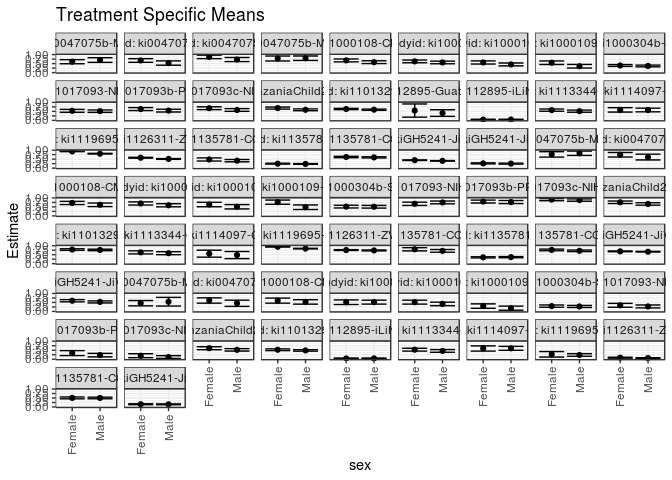

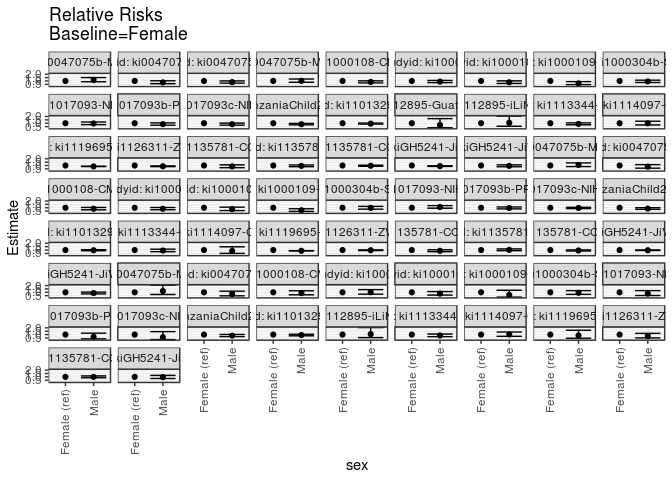

[figure not shown]

[figure not shown]

## Results Table

### Parameter: TSM

| agecat | studyid | country | intervention_level | baseline_level | estimate | ci_lower | ci_upper |
| --- | --- | --- | --- | --- | --- | --- | --- |
| 0-24 months | ki0047075b-MAL-ED | BANGLADESH | Female | NA | 0.6056338 | 0.4924847 | 0.7187829 |
| 0-24 months | ki0047075b-MAL-ED | BANGLADESH | Male | NA | 0.6981132 | 0.5678868 | 0.8283396 |
| 0-24 months | ki0047075b-MAL-ED | INDIA | Female | NA | 0.6734694 | 0.5725923 | 0.7743465 |
| 0-24 months | ki0047075b-MAL-ED | INDIA | Male | NA | 0.5301205 | 0.4108727 | 0.6493683 |
| 0-24 months | ki0047075b-MAL-ED | NEPAL | Female | NA | 0.8723404 | 0.7752792 | 0.9694016 |
| 0-24 months | ki0047075b-MAL-ED | NEPAL | Male | NA | 0.7254902 | 0.6122021 | 0.8387783 |
| 0-24 months | ki0047075b-MAL-ED | SOUTH AFRICA | Female | NA | 0.7837838 | 0.6465498 | 0.9210178 |
| 0-24 months | ki0047075b-MAL-ED | SOUTH AFRICA | Male | NA | 0.8000000 | 0.6771747 | 0.9228253 |
| 0-24 months | ki1000108-CMC-V-BCS-2002 | INDIA | Female | NA | 0.6790123 | 0.5991874 | 0.7588373 |
| 0-24 months | ki1000108-CMC-V-BCS-2002 | INDIA | Male | NA | 0.5802469 | 0.5020417 | 0.6584521 |
| 0-24 months | ki1000108-IRC | INDIA | Female | NA | 0.6222222 | 0.5459703 | 0.6984741 |
| 0-24 months | ki1000108-IRC | INDIA | Male | NA | 0.5627907 | 0.4915511 | 0.6340303 |
| 0-24 months | ki1000109-EE | PAKISTAN | Female | NA | 0.5629139 | 0.4763987 | 0.6494291 |
| 0-24 months | ki1000109-EE | PAKISTAN | Male | NA | 0.4534884 | 0.3741281 | 0.5328486 |
| 0-24 months | ki1000109-ResPak | PAKISTAN | Female | NA | 0.5490196 | 0.4513658 | 0.6466735 |
| 0-24 months | ki1000109-ResPak | PAKISTAN | Male | NA | 0.3529412 | 0.2523570 | 0.4535254 |
| 0-24 months | ki1000304b-SAS-CompFeed | INDIA | Female | NA | 0.3957784 | 0.3451643 | 0.4463924 |
| 0-24 months | ki1000304b-SAS-CompFeed | INDIA | Male | NA | 0.3678161 | 0.3192002 | 0.4164320 |
| 0-24 months | ki1017093-NIH-Birth | BANGLADESH | Female | NA | 0.5300546 | 0.4507893 | 0.6093200 |
| 0-24 months | ki1017093-NIH-Birth | BANGLADESH | Male | NA | 0.5126050 | 0.4470001 | 0.5782100 |
| 0-24 months | ki1017093b-PROVIDE | BANGLADESH | Female | NA | 0.6267606 | 0.5442282 | 0.7092930 |
| 0-24 months | ki1017093b-PROVIDE | BANGLADESH | Male | NA | 0.5421687 | 0.4645723 | 0.6197651 |
| 0-24 months | ki1017093c-NIH-Crypto | BANGLADESH | Female | NA | 0.6760563 | 0.5985746 | 0.7535381 |
| 0-24 months | ki1017093c-NIH-Crypto | BANGLADESH | Male | NA | 0.5773810 | 0.5024193 | 0.6523426 |
| 0-24 months | ki1066203-TanzaniaChild2 | TANZANIA, UNITED REPUBLIC OF | Female | NA | 0.6824324 | 0.6259632 | 0.7389017 |
| 0-24 months | ki1066203-TanzaniaChild2 | TANZANIA, UNITED REPUBLIC OF | Male | NA | 0.5875300 | 0.5378588 | 0.6372012 |
| 0-24 months | ki1101329-Keneba | GAMBIA | Female | NA | 0.6311275 | 0.5954476 | 0.6668073 |
| 0-24 months | ki1101329-Keneba | GAMBIA | Male | NA | 0.5938735 | 0.5612088 | 0.6265383 |
| 0-24 months | ki1112895-Guatemala BSC | GUATEMALA | Female | NA | 0.5454545 | 0.1787960 | 0.9121131 |
| 0-24 months | ki1112895-Guatemala BSC | GUATEMALA | Male | NA | 0.4074074 | 0.2232840 | 0.5915308 |

[output cut: 100 more lines]

### Parameter: E(Y)

| agecat | studyid | country | intervention_level | baseline_level | estimate | ci_lower | ci_upper |
| --- | --- | --- | --- | --- | --- | --- | --- |
| 0-24 months | ki0047075b-MAL-ED | BANGLADESH | NA | NA | 0.6451613 | 0.5593015 | 0.7310211 |
| 0-24 months | ki0047075b-MAL-ED | INDIA | NA | NA | 0.6077348 | 0.5286689 | 0.6868008 |
| 0-24 months | ki0047075b-MAL-ED | NEPAL | NA | NA | 0.7959184 | 0.7207268 | 0.8711100 |
| 0-24 months | ki0047075b-MAL-ED | SOUTH AFRICA | NA | NA | 0.7931034 | 0.7014938 | 0.8847131 |
| 0-24 months | ki1000108-CMC-V-BCS-2002 | INDIA | NA | NA | 0.6296296 | 0.5734927 | 0.6857666 |
| 0-24 months | ki1000108-IRC | INDIA | NA | NA | 0.5898734 | 0.5376978 | 0.6420491 |
| 0-24 months | ki1000109-EE | PAKISTAN | NA | NA | 0.5046440 | 0.4456009 | 0.5636870 |
| 0-24 months | ki1000109-ResPak | PAKISTAN | NA | NA | 0.4509804 | 0.3794254 | 0.5225353 |
| 0-24 months | ki1000304b-SAS-CompFeed | INDIA | NA | NA | 0.3808354 | 0.3457640 | 0.4159068 |
| 0-24 months | ki1017093-NIH-Birth | BANGLADESH | NA | NA | 0.5201900 | 0.4695846 | 0.5707955 |
| 0-24 months | ki1017093b-PROVIDE | BANGLADESH | NA | NA | 0.5811688 | 0.5245443 | 0.6377934 |
| 0-24 months | ki1017093c-NIH-Crypto | BANGLADESH | NA | NA | 0.6225806 | 0.5684562 | 0.6767051 |
| 0-24 months | ki1066203-TanzaniaChild2 | TANZANIA, UNITED REPUBLIC OF | NA | NA | 0.6269285 | 0.5892870 | 0.6645700 |
| 0-24 months | ki1101329-Keneba | GAMBIA | NA | NA | 0.6105033 | 0.5863646 | 0.6346419 |
| 0-24 months | ki1112895-Guatemala BSC | GUATEMALA | NA | NA | 0.4473684 | 0.2760904 | 0.6186464 |
| 0-24 months | ki1112895-iLiNS-Zinc | BURKINA FASO | NA | NA | 0.0439024 | 0.0298653 | 0.0579396 |
| 0-24 months | ki1113344-GMS-Nepal | NEPAL | NA | NA | 0.5396579 | 0.4973524 | 0.5819633 |
| 0-24 months | ki1114097-CMIN | BANGLADESH | NA | NA | 0.5789474 | 0.5004470 | 0.6574477 |
| 0-24 months | ki1119695-PROBIT | BELARUS | NA | NA | 0.8612051 | 0.8511051 | 0.8713052 |
| 0-24 months | ki1126311-ZVITAMBO | ZIMBABWE | NA | NA | 0.5432918 | 0.5268968 | 0.5596869 |
| 0-24 months | ki1135781-COHORTS | GUATEMALA | NA | NA | 0.4409449 | 0.3893635 | 0.4925263 |
| 0-24 months | ki1135781-COHORTS | INDIA | NA | NA | 0.2418325 | 0.2254819 | 0.2581831 |
| 0-24 months | ki1135781-COHORTS | PHILIPPINES | NA | NA | 0.6068680 | 0.5823645 | 0.6313715 |
| 0-24 months | kiGH5241-JiVitA-3 | BANGLADESH | NA | NA | 0.4221371 | 0.4110175 | 0.4332567 |
| 0-24 months | kiGH5241-JiVitA-4 | BANGLADESH | NA | NA | 0.2585790 | 0.2392503 | 0.2779077 |
| 0-6 months | ki0047075b-MAL-ED | BANGLADESH | NA | NA | 0.7936508 | 0.6942781 | 0.8930235 |
| 0-6 months | ki0047075b-MAL-ED | INDIA | NA | NA | 0.6860465 | 0.5849088 | 0.7871842 |
| 0-6 months | ki1000108-CMC-V-BCS-2002 | INDIA | NA | NA | 0.6716418 | 0.6057305 | 0.7375531 |
| 0-6 months | ki1000108-IRC | INDIA | NA | NA | 0.6375000 | 0.5751450 | 0.6998550 |
| 0-6 months | ki1000109-EE | PAKISTAN | NA | NA | 0.5669291 | 0.4800274 | 0.6538309 |
| 0-6 months | ki1000109-ResPak | PAKISTAN | NA | NA | 0.6194690 | 0.5292383 | 0.7096997 |
| 0-6 months | ki1000304b-SAS-CompFeed | INDIA | NA | NA | 0.5131965 | 0.4596632 | 0.5667297 |
| 0-6 months | ki1017093-NIH-Birth | BANGLADESH | NA | NA | 0.7130045 | 0.6535890 | 0.7724200 |
| 0-6 months | ki1017093b-PROVIDE | BANGLADESH | NA | NA | 0.7837838 | 0.7252863 | 0.8422812 |
| 0-6 months | ki1017093c-NIH-Crypto | BANGLADESH | NA | NA | 0.8934010 | 0.8497799 | 0.9370221 |
| 0-6 months | ki1066203-TanzaniaChild2 | TANZANIA, UNITED REPUBLIC OF | NA | NA | 0.7029412 | 0.6536517 | 0.7522307 |
| 0-6 months | ki1101329-Keneba | GAMBIA | NA | NA | 0.7720994 | 0.7419223 | 0.8022766 |
| 0-6 months | ki1113344-GMS-Nepal | NEPAL | NA | NA | 0.6045627 | 0.5449300 | 0.6641955 |
| 0-6 months | ki1114097-CMIN | BANGLADESH | NA | NA | 0.5192308 | 0.3806687 | 0.6577929 |
| 0-6 months | ki1119695-PROBIT | BELARUS | NA | NA | 0.8855266 | 0.8758983 | 0.8951550 |
| 0-6 months | ki1126311-ZVITAMBO | ZIMBABWE | NA | NA | 0.7475189 | 0.7305656 | 0.7644721 |
| 0-6 months | ki1135781-COHORTS | GUATEMALA | NA | NA | 0.7441860 | 0.6858573 | 0.8025148 |
| 0-6 months | ki1135781-COHORTS | INDIA | NA | NA | 0.3585746 | 0.3363886 | 0.3807606 |
| 0-6 months | ki1135781-COHORTS | PHILIPPINES | NA | NA | 0.7367021 | 0.7051294 | 0.7682749 |
| 0-6 months | kiGH5241-JiVitA-3 | BANGLADESH | NA | NA | 0.6751162 | 0.6617750 | 0.6884574 |
| 0-6 months | kiGH5241-JiVitA-4 | BANGLADESH | NA | NA | 0.5587703 | 0.5173487 | 0.6001920 |
| 6-24 months | ki0047075b-MAL-ED | BANGLADESH | NA | NA | 0.4918033 | 0.3610932 | 0.6225134 |
| 6-24 months | ki0047075b-MAL-ED | INDIA | NA | NA | 0.5368421 | 0.4223932 | 0.6512910 |
| 6-24 months | ki1000108-CMC-V-BCS-2002 | INDIA | NA | NA | 0.5609756 | 0.4682842 | 0.6536670 |
| 6-24 months | ki1000108-IRC | INDIA | NA | NA | 0.5161290 | 0.4322562 | 0.6000019 |
| 6-24 months | ki1000109-EE | PAKISTAN | NA | NA | 0.4642857 | 0.3910729 | 0.5374985 |
| 6-24 months | ki1000109-ResPak | PAKISTAN | NA | NA | 0.2417582 | 0.1565924 | 0.3269241 |
| 6-24 months | ki1000304b-SAS-CompFeed | INDIA | NA | NA | 0.2854123 | 0.2436284 | 0.3271961 |
| 6-24 months | ki1017093-NIH-Birth | BANGLADESH | NA | NA | 0.3030303 | 0.2377927 | 0.3682679 |
| 6-24 months | ki1017093b-PROVIDE | BANGLADESH | NA | NA | 0.2764228 | 0.1950773 | 0.3577682 |
| 6-24 months | ki1017093c-NIH-Crypto | BANGLADESH | NA | NA | 0.1504425 | 0.0860251 | 0.2148599 |
| 6-24 months | ki1066203-TanzaniaChild2 | TANZANIA, UNITED REPUBLIC OF | NA | NA | 0.5576408 | 0.5054408 | 0.6098407 |
| 6-24 months | ki1101329-Keneba | GAMBIA | NA | NA | 0.5045290 | 0.4730969 | 0.5359611 |
| 6-24 months | ki1112895-iLiNS-Zinc | BURKINA FASO | NA | NA | 0.0439024 | 0.0298653 | 0.0579396 |
| 6-24 months | ki1113344-GMS-Nepal | NEPAL | NA | NA | 0.4947368 | 0.4401559 | 0.5493178 |
| 6-24 months | ki1114097-CMIN | BANGLADESH | NA | NA | 0.6014493 | 0.5131344 | 0.6897641 |
| 6-24 months | ki1119695-PROBIT | BELARUS | NA | NA | 0.2440476 | 0.1791134 | 0.3089818 |
| 6-24 months | ki1126311-ZVITAMBO | ZIMBABWE | NA | NA | 0.0739051 | 0.0584895 | 0.0893208 |
| 6-24 months | ki1135781-COHORTS | PHILIPPINES | NA | NA | 0.5026681 | 0.4688378 | 0.5364984 |
| 6-24 months | kiGH5241-JiVitA-4 | BANGLADESH | NA | NA | 0.1490765 | 0.1314900 | 0.1666630 |

### Parameter: RR

| agecat | studyid | country | intervention_level | baseline_level | estimate | ci_lower | ci_upper |
| --- | --- | --- | --- | --- | --- | --- | --- |
| 0-24 months | ki0047075b-MAL-ED | BANGLADESH | Female | Female | 1.0000000 | 1.0000000 | 1.0000000 |
| 0-24 months | ki0047075b-MAL-ED | BANGLADESH | Male | Female | 1.1526986 | 0.8850408 | 1.5013025 |
| 0-24 months | ki0047075b-MAL-ED | INDIA | Female | Female | 1.0000000 | 1.0000000 | 1.0000000 |
| 0-24 months | ki0047075b-MAL-ED | INDIA | Male | Female | 0.7871486 | 0.6008307 | 1.0312438 |
| 0-24 months | ki0047075b-MAL-ED | NEPAL | Female | Female | 1.0000000 | 1.0000000 | 1.0000000 |
| 0-24 months | ki0047075b-MAL-ED | NEPAL | Male | Female | 0.8316595 | 0.6864168 | 1.0076349 |
| 0-24 months | ki0047075b-MAL-ED | SOUTH AFRICA | Female | Female | 1.0000000 | 1.0000000 | 1.0000000 |
| 0-24 months | ki0047075b-MAL-ED | SOUTH AFRICA | Male | Female | 1.0206897 | 0.8090669 | 1.2876653 |
| 0-24 months | ki1000108-CMC-V-BCS-2002 | INDIA | Female | Female | 1.0000000 | 1.0000000 | 1.0000000 |
| 0-24 months | ki1000108-CMC-V-BCS-2002 | INDIA | Male | Female | 0.8545455 | 0.7145954 | 1.0219040 |
| 0-24 months | ki1000108-IRC | INDIA | Female | Female | 1.0000000 | 1.0000000 | 1.0000000 |
| 0-24 months | ki1000108-IRC | INDIA | Male | Female | 0.9044850 | 0.7583690 | 1.0787535 |
| 0-24 months | ki1000109-EE | PAKISTAN | Female | Female | 1.0000000 | 1.0000000 | 1.0000000 |
| 0-24 months | ki1000109-EE | PAKISTAN | Male | Female | 0.8056088 | 0.6382301 | 1.0168832 |
| 0-24 months | ki1000109-ResPak | PAKISTAN | Female | Female | 1.0000000 | 1.0000000 | 1.0000000 |
| 0-24 months | ki1000109-ResPak | PAKISTAN | Male | Female | 0.6428571 | 0.4593702 | 0.8996345 |
| 0-24 months | ki1000304b-SAS-CompFeed | INDIA | Female | Female | 1.0000000 | 1.0000000 | 1.0000000 |
| 0-24 months | ki1000304b-SAS-CompFeed | INDIA | Male | Female | 0.9293487 | 0.7732151 | 1.1170100 |
| 0-24 months | ki1017093-NIH-Birth | BANGLADESH | Female | Female | 1.0000000 | 1.0000000 | 1.0000000 |
| 0-24 months | ki1017093-NIH-Birth | BANGLADESH | Male | Female | 0.9670796 | 0.7942192 | 1.1775628 |
| 0-24 months | ki1017093b-PROVIDE | BANGLADESH | Female | Female | 1.0000000 | 1.0000000 | 1.0000000 |
| 0-24 months | ki1017093b-PROVIDE | BANGLADESH | Male | Female | 0.8650332 | 0.7120302 | 1.0509138 |
| 0-24 months | ki1017093c-NIH-Crypto | BANGLADESH | Female | Female | 1.0000000 | 1.0000000 | 1.0000000 |
| 0-24 months | ki1017093c-NIH-Crypto | BANGLADESH | Male | Female | 0.8540427 | 0.7179611 | 1.0159170 |
| 0-24 months | ki1066203-TanzaniaChild2 | TANZANIA, UNITED REPUBLIC OF | Female | Female | 1.0000000 | 1.0000000 | 1.0000000 |
| 0-24 months | ki1066203-TanzaniaChild2 | TANZANIA, UNITED REPUBLIC OF | Male | Female | 0.8609350 | 0.7648976 | 0.9690305 |
| 0-24 months | ki1101329-Keneba | GAMBIA | Female | Female | 1.0000000 | 1.0000000 | 1.0000000 |
| 0-24 months | ki1101329-Keneba | GAMBIA | Male | Female | 0.9409724 | 0.8696096 | 1.0181915 |
| 0-24 months | ki1112895-Guatemala BSC | GUATEMALA | Female | Female | 1.0000000 | 1.0000000 | 1.0000000 |
| 0-24 months | ki1112895-Guatemala BSC | GUATEMALA | Male | Female | 0.7469136 | 0.3322681 | 1.6790053 |

[output cut: 100 more lines]

### Parameter: PAR

| agecat | studyid | country | intervention_level | baseline_level | estimate | ci_lower | ci_upper |
| --- | --- | --- | --- | --- | --- | --- | --- |
| 0-24 months | ki0047075b-MAL-ED | BANGLADESH | Female | NA | 0.0395275 | -0.0354608 | 0.1145158 |
| 0-24 months | ki0047075b-MAL-ED | INDIA | Female | NA | -0.0657346 | -0.1387981 | 0.0073289 |
| 0-24 months | ki0047075b-MAL-ED | NEPAL | Female | NA | -0.0764221 | -0.1539679 | 0.0011237 |
| 0-24 months | ki0047075b-MAL-ED | SOUTH AFRICA | Female | NA | 0.0093197 | -0.0964298 | 0.1150691 |
| 0-24 months | ki1000108-CMC-V-BCS-2002 | INDIA | Female | NA | -0.0493827 | -0.1054959 | 0.0067305 |
| 0-24 months | ki1000108-IRC | INDIA | Female | NA | -0.0323488 | -0.0892066 | 0.0245090 |
| 0-24 months | ki1000109-EE | PAKISTAN | Female | NA | -0.0582699 | -0.1212556 | 0.0047157 |
| 0-24 months | ki1000109-ResPak | PAKISTAN | Female | NA | -0.0980392 | -0.1704790 | -0.0255994 |
| 0-24 months | ki1000304b-SAS-CompFeed | INDIA | Female | NA | -0.0149430 | -0.0524931 | 0.0226071 |
| 0-24 months | ki1017093-NIH-Birth | BANGLADESH | Female | NA | -0.0098646 | -0.0680249 | 0.0482957 |
| 0-24 months | ki1017093b-PROVIDE | BANGLADESH | Female | NA | -0.0455917 | -0.1066063 | 0.0154229 |
| 0-24 months | ki1017093c-NIH-Crypto | BANGLADESH | Female | NA | -0.0534757 | -0.1117721 | 0.0048207 |
| 0-24 months | ki1066203-TanzaniaChild2 | TANZANIA, UNITED REPUBLIC OF | Female | NA | -0.0555040 | -0.0996610 | -0.0113469 |
| 0-24 months | ki1101329-Keneba | GAMBIA | Female | NA | -0.0206242 | -0.0474176 | 0.0061693 |
| 0-24 months | ki1112895-Guatemala BSC | GUATEMALA | Female | NA | -0.0980861 | -0.3912445 | 0.1950722 |
| 0-24 months | ki1112895-iLiNS-Zinc | BURKINA FASO | Female | NA | 0.0015296 | -0.0146114 | 0.0176705 |
| 0-24 months | ki1113344-GMS-Nepal | NEPAL | Female | NA | -0.0294740 | -0.0732576 | 0.0143096 |
| 0-24 months | ki1114097-CMIN | BANGLADESH | Female | NA | -0.0043860 | -0.0932229 | 0.0844510 |
| 0-24 months | ki1119695-PROBIT | BELARUS | Female | NA | -0.0669473 | -0.0775195 | -0.0563752 |
| 0-24 months | ki1126311-ZVITAMBO | ZIMBABWE | Female | NA | -0.0344357 | -0.0511636 | -0.0177078 |
| 0-24 months | ki1135781-COHORTS | GUATEMALA | Female | NA | -0.0413246 | -0.1091054 | 0.0264562 |
| 0-24 months | ki1135781-COHORTS | INDIA | Female | NA | -0.0075737 | -0.0248091 | 0.0096618 |
| 0-24 months | ki1135781-COHORTS | PHILIPPINES | Female | NA | -0.0125045 | -0.0405600 | 0.0155510 |
| 0-24 months | kiGH5241-JiVitA-3 | BANGLADESH | Female | NA | -0.0202390 | -0.0317640 | -0.0087141 |
| 0-24 months | kiGH5241-JiVitA-4 | BANGLADESH | Female | NA | -0.0081574 | -0.0290609 | 0.0127462 |
| 0-6 months | ki0047075b-MAL-ED | BANGLADESH | Female | NA | 0.0289449 | -0.0608658 | 0.1187557 |
| 0-6 months | ki0047075b-MAL-ED | INDIA | Female | NA | -0.0586343 | -0.1523361 | 0.0350674 |
| 0-6 months | ki1000108-CMC-V-BCS-2002 | INDIA | Female | NA | -0.0479844 | -0.1101273 | 0.0141586 |
| 0-6 months | ki1000108-IRC | INDIA | Female | NA | -0.0534091 | -0.1208722 | 0.0140540 |
| 0-6 months | ki1000109-EE | PAKISTAN | Female | NA | -0.0664042 | -0.1579267 | 0.0251183 |
| 0-6 months | ki1000109-ResPak | PAKISTAN | Female | NA | -0.1441673 | -0.2366207 | -0.0517140 |
| 0-6 months | ki1000304b-SAS-CompFeed | INDIA | Female | NA | -0.0044506 | -0.0581532 | 0.0492520 |
| 0-6 months | ki1017093-NIH-Birth | BANGLADESH | Female | NA | 0.0399276 | -0.0239813 | 0.1038365 |
| 0-6 months | ki1017093b-PROVIDE | BANGLADESH | Female | NA | -0.0139690 | -0.0744595 | 0.0465215 |
| 0-6 months | ki1017093c-NIH-Crypto | BANGLADESH | Female | NA | -0.0128490 | -0.0574824 | 0.0317845 |
| 0-6 months | ki1066203-TanzaniaChild2 | TANZANIA, UNITED REPUBLIC OF | Female | NA | -0.0540033 | -0.1105430 | 0.0025364 |
| 0-6 months | ki1101329-Keneba | GAMBIA | Female | NA | -0.0116843 | -0.0442383 | 0.0208696 |
| 0-6 months | ki1113344-GMS-Nepal | NEPAL | Female | NA | -0.0244695 | -0.0875431 | 0.0386040 |
| 0-6 months | ki1114097-CMIN | BANGLADESH | Female | NA | -0.0363248 | -0.1699351 | 0.0972855 |
| 0-6 months | ki1119695-PROBIT | BELARUS | Female | NA | -0.0533705 | -0.0633119 | -0.0434292 |
| 0-6 months | ki1126311-ZVITAMBO | ZIMBABWE | Female | NA | -0.0101972 | -0.0266783 | 0.0062839 |
| 0-6 months | ki1135781-COHORTS | GUATEMALA | Female | NA | -0.0558140 | -0.1292671 | 0.0176392 |
| 0-6 months | ki1135781-COHORTS | INDIA | Female | NA | 0.0050393 | -0.0173193 | 0.0273978 |
| 0-6 months | ki1135781-COHORTS | PHILIPPINES | Female | NA | -0.0280038 | -0.0640678 | 0.0080603 |
| 0-6 months | kiGH5241-JiVitA-3 | BANGLADESH | Female | NA | -0.0102104 | -0.0236015 | 0.0031807 |
| 0-6 months | kiGH5241-JiVitA-4 | BANGLADESH | Female | NA | -0.0363714 | -0.0823745 | 0.0096317 |
| 6-24 months | ki0047075b-MAL-ED | BANGLADESH | Female | NA | 0.0323438 | -0.0789551 | 0.1436427 |
| 6-24 months | ki0047075b-MAL-ED | INDIA | Female | NA | -0.0710010 | -0.1778074 | 0.0358054 |
| 6-24 months | ki1000108-CMC-V-BCS-2002 | INDIA | Female | NA | -0.0390244 | -0.1425519 | 0.0645031 |
| 6-24 months | ki1000108-IRC | INDIA | Female | NA | 0.0018433 | -0.0910601 | 0.0947468 |
| 6-24 months | ki1000109-EE | PAKISTAN | Female | NA | -0.0521978 | -0.1311896 | 0.0267940 |
| 6-24 months | ki1000109-ResPak | PAKISTAN | Female | NA | -0.0561141 | -0.1392879 | 0.0270597 |
| 6-24 months | ki1000304b-SAS-CompFeed | INDIA | Female | NA | -0.0112385 | -0.0581254 | 0.0356485 |
| 6-24 months | ki1017093-NIH-Birth | BANGLADESH | Female | NA | -0.0387418 | -0.1204938 | 0.0430101 |
| 6-24 months | ki1017093b-PROVIDE | BANGLADESH | Female | NA | -0.0631999 | -0.1597422 | 0.0333424 |
| 6-24 months | ki1017093c-NIH-Crypto | BANGLADESH | Female | NA | -0.0452097 | -0.1253444 | 0.0349250 |
| 6-24 months | ki1066203-TanzaniaChild2 | TANZANIA, UNITED REPUBLIC OF | Female | NA | -0.0542014 | -0.1171768 | 0.0087741 |
| 6-24 months | ki1101329-Keneba | GAMBIA | Female | NA | -0.0213509 | -0.0570980 | 0.0143961 |
| 6-24 months | ki1112895-iLiNS-Zinc | BURKINA FASO | Female | NA | 0.0015296 | -0.0146114 | 0.0176705 |
| 6-24 months | ki1113344-GMS-Nepal | NEPAL | Female | NA | -0.0346749 | -0.0904617 | 0.0211119 |
| 6-24 months | ki1114097-CMIN | BANGLADESH | Female | NA | 0.0049580 | -0.1021649 | 0.1120810 |
| 6-24 months | ki1119695-PROBIT | BELARUS | Female | NA | -0.0286797 | -0.1646529 | 0.1072936 |
| 6-24 months | ki1126311-ZVITAMBO | ZIMBABWE | Female | NA | -0.0106615 | -0.0286408 | 0.0073178 |
| 6-24 months | ki1135781-COHORTS | PHILIPPINES | Female | NA | -0.0022100 | -0.0406903 | 0.0362703 |
| 6-24 months | kiGH5241-JiVitA-4 | BANGLADESH | Female | NA | -0.0032507 | -0.0220415 | 0.0155401 |

### Parameter: PAF

| agecat | studyid | country | intervention_level | baseline_level | estimate | ci_lower | ci_upper |
| --- | --- | --- | --- | --- | --- | --- | --- |
| 0-24 months | ki0047075b-MAL-ED | BANGLADESH | Female | NA | 0.0612676 | -0.0626521 | 0.1707366 |
| 0-24 months | ki0047075b-MAL-ED | INDIA | Female | NA | -0.1081633 | -0.2379603 | 0.0080249 |
| 0-24 months | ki0047075b-MAL-ED | NEPAL | Female | NA | -0.0960175 | -0.2002561 | -0.0008316 |
| 0-24 months | ki0047075b-MAL-ED | SOUTH AFRICA | Female | NA | 0.0117509 | -0.1309474 | 0.1364441 |
| 0-24 months | ki1000108-CMC-V-BCS-2002 | INDIA | Female | NA | -0.0784314 | -0.1715493 | 0.0072853 |
| 0-24 months | ki1000108-IRC | INDIA | Female | NA | -0.0548402 | -0.1560309 | 0.0374929 |
| 0-24 months | ki1000109-EE | PAKISTAN | Female | NA | -0.1154674 | -0.2482818 | 0.0032158 |
| 0-24 months | ki1000109-ResPak | PAKISTAN | Female | NA | -0.2173913 | -0.3963554 | -0.0613642 |
| 0-24 months | ki1000304b-SAS-CompFeed | INDIA | Female | NA | -0.0392374 | -0.1428561 | 0.0549866 |
| 0-24 months | ki1017093-NIH-Birth | BANGLADESH | Female | NA | -0.0189635 | -0.1370321 | 0.0868450 |
| 0-24 months | ki1017093b-PROVIDE | BANGLADESH | Female | NA | -0.0784483 | -0.1891636 | 0.0219589 |
| 0-24 months | ki1017093c-NIH-Crypto | BANGLADESH | Female | NA | -0.0858936 | -0.1844267 | 0.0044424 |
| 0-24 months | ki1066203-TanzaniaChild2 | TANZANIA, UNITED REPUBLIC OF | Female | NA | -0.0885332 | -0.1618118 | -0.0198765 |
| 0-24 months | ki1101329-Keneba | GAMBIA | Female | NA | -0.0337822 | -0.0786654 | 0.0092334 |
| 0-24 months | ki1112895-Guatemala BSC | GUATEMALA | Female | NA | -0.2192513 | -1.0686490 | 0.2813794 |
| 0-24 months | ki1112895-iLiNS-Zinc | BURKINA FASO | Female | NA | 0.0348399 | -0.4131544 | 0.3408123 |
| 0-24 months | ki1113344-GMS-Nepal | NEPAL | Female | NA | -0.0546160 | -0.1391547 | 0.0236488 |
| 0-24 months | ki1114097-CMIN | BANGLADESH | Female | NA | -0.0075758 | -0.1732498 | 0.1347035 |
| 0-24 months | ki1119695-PROBIT | BELARUS | Female | NA | -0.0777368 | -0.0904810 | -0.0651416 |
| 0-24 months | ki1126311-ZVITAMBO | ZIMBABWE | Female | NA | -0.0633834 | -0.0946733 | -0.0329879 |
| 0-24 months | ki1135781-COHORTS | GUATEMALA | Female | NA | -0.0937183 | -0.2588142 | 0.0497249 |
| 0-24 months | ki1135781-COHORTS | INDIA | Female | NA | -0.0313178 | -0.1050949 | 0.0375340 |
| 0-24 months | ki1135781-COHORTS | PHILIPPINES | Female | NA | -0.0206049 | -0.0678852 | 0.0245820 |
| 0-24 months | kiGH5241-JiVitA-3 | BANGLADESH | Female | NA | -0.0479442 | -0.0756075 | -0.0209924 |
| 0-24 months | kiGH5241-JiVitA-4 | BANGLADESH | Female | NA | -0.0315469 | -0.1155974 | 0.0461711 |
| 0-6 months | ki0047075b-MAL-ED | BANGLADESH | Female | NA | 0.0364706 | -0.0850960 | 0.1444177 |
| 0-6 months | ki0047075b-MAL-ED | INDIA | Female | NA | -0.0854670 | -0.2339432 | 0.0451435 |
| 0-6 months | ki1000108-CMC-V-BCS-2002 | INDIA | Female | NA | -0.0714434 | -0.1687542 | 0.0177652 |
| 0-6 months | ki1000108-IRC | INDIA | Female | NA | -0.0837790 | -0.1961512 | 0.0180364 |
| 0-6 months | ki1000109-EE | PAKISTAN | Female | NA | -0.1171296 | -0.2929855 | 0.0348085 |
| 0-6 months | ki1000109-ResPak | PAKISTAN | Female | NA | -0.2327273 | -0.4025012 | -0.0835046 |
| 0-6 months | ki1000304b-SAS-CompFeed | INDIA | Female | NA | -0.0086723 | -0.1189321 | 0.0907226 |
| 0-6 months | ki1017093-NIH-Birth | BANGLADESH | Female | NA | 0.0559990 | -0.0385811 | 0.1419661 |
| 0-6 months | ki1017093b-PROVIDE | BANGLADESH | Female | NA | -0.0178225 | -0.0981491 | 0.0566283 |
| 0-6 months | ki1017093c-NIH-Crypto | BANGLADESH | Female | NA | -0.0143821 | -0.0656755 | 0.0344425 |
| 0-6 months | ki1066203-TanzaniaChild2 | TANZANIA, UNITED REPUBLIC OF | Female | NA | -0.0768247 | -0.1611932 | 0.0014138 |
| 0-6 months | ki1101329-Keneba | GAMBIA | Female | NA | -0.0151332 | -0.0582192 | 0.0261985 |
| 0-6 months | ki1113344-GMS-Nepal | NEPAL | Female | NA | -0.0404747 | -0.1504154 | 0.0589593 |
| 0-6 months | ki1114097-CMIN | BANGLADESH | Female | NA | -0.0699588 | -0.3613715 | 0.1590746 |
| 0-6 months | ki1119695-PROBIT | BELARUS | Female | NA | -0.0602698 | -0.0718523 | -0.0488125 |
| 0-6 months | ki1126311-ZVITAMBO | ZIMBABWE | Female | NA | -0.0136414 | -0.0359411 | 0.0081783 |
| 0-6 months | ki1135781-COHORTS | GUATEMALA | Female | NA | -0.0750000 | -0.1793207 | 0.0200927 |
| 0-6 months | ki1135781-COHORTS | INDIA | Female | NA | 0.0140536 | -0.0503149 | 0.0744772 |
| 0-6 months | ki1135781-COHORTS | PHILIPPINES | Female | NA | -0.0380123 | -0.0882674 | 0.0099220 |
| 0-6 months | kiGH5241-JiVitA-3 | BANGLADESH | Female | NA | -0.0151239 | -0.0351616 | 0.0045260 |
| 0-6 months | kiGH5241-JiVitA-4 | BANGLADESH | Female | NA | -0.0650918 | -0.1509455 | 0.0143577 |
| 6-24 months | ki0047075b-MAL-ED | BANGLADESH | Female | NA | 0.0657658 | -0.1850068 | 0.2634695 |
| 6-24 months | ki0047075b-MAL-ED | INDIA | Female | NA | -0.1322568 | -0.3555995 | 0.0542889 |
| 6-24 months | ki1000108-CMC-V-BCS-2002 | INDIA | Female | NA | -0.0695652 | -0.2710891 | 0.1000082 |
| 6-24 months | ki1000108-IRC | INDIA | Female | NA | 0.0035714 | -0.1937502 | 0.1682767 |
| 6-24 months | ki1000109-EE | PAKISTAN | Female | NA | -0.1124260 | -0.2967413 | 0.0456912 |
| 6-24 months | ki1000109-ResPak | PAKISTAN | Female | NA | -0.2321083 | -0.6342734 | 0.0710912 |
| 6-24 months | ki1000304b-SAS-CompFeed | INDIA | Female | NA | -0.0393762 | -0.2175562 | 0.1127285 |
| 6-24 months | ki1017093-NIH-Birth | BANGLADESH | Female | NA | -0.1278481 | -0.4317672 | 0.1115586 |
| 6-24 months | ki1017093b-PROVIDE | BANGLADESH | Female | NA | -0.2286349 | -0.6256733 | 0.0714348 |
| 6-24 months | ki1017093c-NIH-Crypto | BANGLADESH | Female | NA | -0.3005115 | -0.9557483 | 0.1352005 |
| 6-24 months | ki1066203-TanzaniaChild2 | TANZANIA, UNITED REPUBLIC OF | Female | NA | -0.0971976 | -0.2165771 | 0.0104674 |
| 6-24 months | ki1101329-Keneba | GAMBIA | Female | NA | -0.0423185 | -0.1156658 | 0.0262066 |
| 6-24 months | ki1112895-iLiNS-Zinc | BURKINA FASO | Female | NA | 0.0348399 | -0.4131544 | 0.3408123 |
| 6-24 months | ki1113344-GMS-Nepal | NEPAL | Female | NA | -0.0700876 | -0.1890324 | 0.0369585 |
| 6-24 months | ki1114097-CMIN | BANGLADESH | Female | NA | 0.0082435 | -0.1870189 | 0.1713856 |
| 6-24 months | ki1119695-PROBIT | BELARUS | Female | NA | -0.1175166 | -0.8389439 | 0.3208910 |
| 6-24 months | ki1126311-ZVITAMBO | ZIMBABWE | Female | NA | -0.1442591 | -0.4134115 | 0.0736392 |
| 6-24 months | ki1135781-COHORTS | PHILIPPINES | Female | NA | -0.0043965 | -0.0839333 | 0.0693041 |
| 6-24 months | kiGH5241-JiVitA-4 | BANGLADESH | Female | NA | -0.0218056 | -0.1559442 | 0.0967672 |